# Exercício: SARIMA no comércio varejista brasileiro

# Sobre o exercício

A base é a **PMC** (Pesquisa Mensal do Comércio) do IBGE: índice de volume de vendas no **comércio varejista ampliado** (inclui veículos e materiais de construção), por **Unidade da Federação**, mensal de jan/2004 em diante. Base 2022 = 100, **sem ajuste sazonal**.

Você receberá **uma UF de interesse**, e deve aplicar a análise abaixo:

Setup

1. Criar repositório no GitHub para o exercício, e configurar o GitHub Pages para servir o conteúdo do repositório.
2. Clonar o repositório e criar um arquivo chamado `template-exercicio-sarima.qmd` (pode usar o template deste exercício, ou criar do zero, e pode usar jupyter notebook no lugar de Quarto, basta converter usando o comando `quarto convert`).
3. Configure o `uv` com um `.venv` para gerenciar as dependências do exercício (pode usar o `requirements.txt` deste repositório como base, ou criar o seu do zero). Obs: Não é para subir a pasta `.venv` no GitHub, ele precisa estar no seu `.gitignore`.

Código

3. Análise descritiva (linha, ACF, PACF, diferenciação) e diagnóstico de tendência/sazonalidade.
4. Testes de raiz unitária (ADF, KPSS) e estimativa de `ndiffs`.
5. Ajuste de SARIMA via `AutoARIMA(season_length=12)`.
6. Diagnóstico dos resíduos.
7. Previsão de 24 meses à frente, com intervalos de 80% e 95%.

Análise e entrega

8. Discussão dos resultados (perguntas no final).
9. Compilar este arquivo em um relatório em HTML chamado index.html e subir no repositório do GitHub que você criou para este lab.
10. Configure as github pages para servir o conteúdo do repositório, e compartilhe o link no formulário de entrega do BB.

# Setup

```python
import numpy as np
import pandas as pd
import matplotlib.pyplot as plt

from statsmodels.tsa.stattools import adfuller, kpss
from statsmodels.graphics.tsaplots import plot_acf, plot_pacf

from statsforecast import StatsForecast
from statsforecast.models import AutoARIMA, ARIMA
```

# Carregando a base PMC

A base já foi pré-processada para conter apenas as colunas relevantes, e já no formato “long” (uma linha por data + UF). O nome da coluna de data é “data”, e a coluna de interesse (índice de volume) é “volume_idx”. A coluna “uf” indica a Unidade da Federação.

```python
pmc = pd.read_csv("dados/pmc_volume_uf.csv")
```

# Escolha sua UF

```python
MINHA_UF = "São Paulo"


df_sf = (
    pmc.query("uf == @MINHA_UF")
    .rename(columns={"uf": "unique_id", "data": "ds", "volume_idx": "y"})
    [["unique_id", "ds", "y"]]
    .reset_index(drop=True)
)

df_sf.head()
```

|  | unique_id | ds | y |
| --- | --- | --- | --- |
| 0 | São Paulo | 2004-01-01 | 52.53519 |
| 1 | São Paulo | 2004-02-01 | 50.98433 |
| 2 | São Paulo | 2004-03-01 | 57.18775 |
| 3 | São Paulo | 2004-04-01 | 54.76454 |
| 4 | São Paulo | 2004-05-01 | 57.09082 |

# Análise descritiva

```python
import matplotlib.pyplot as plt
from statsmodels.graphics.tsaplots import plot_acf, plot_pacf

df_sf["ds"] = pd.to_datetime(df_sf["ds"])
y = df_sf.set_index("ds")["y"].asfreq("MS")
print(y.isna().sum(), len(y))
```

```
0 266
```

## Gráfico

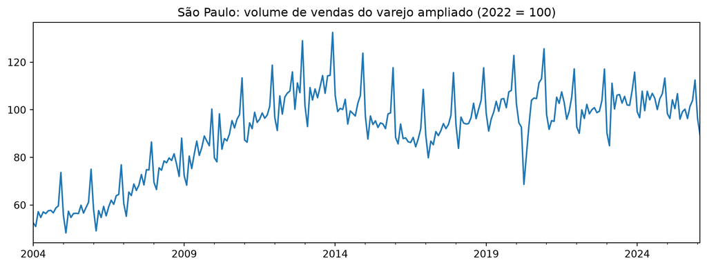

```python
fig, ax = plt.subplots(figsize=(12, 4))
y.plot(ax=ax, title="São Paulo: volume de vendas do varejo ampliado (2022 = 100)")
ax.set_xlabel("")
plt.show()
```

## Sazonalidade

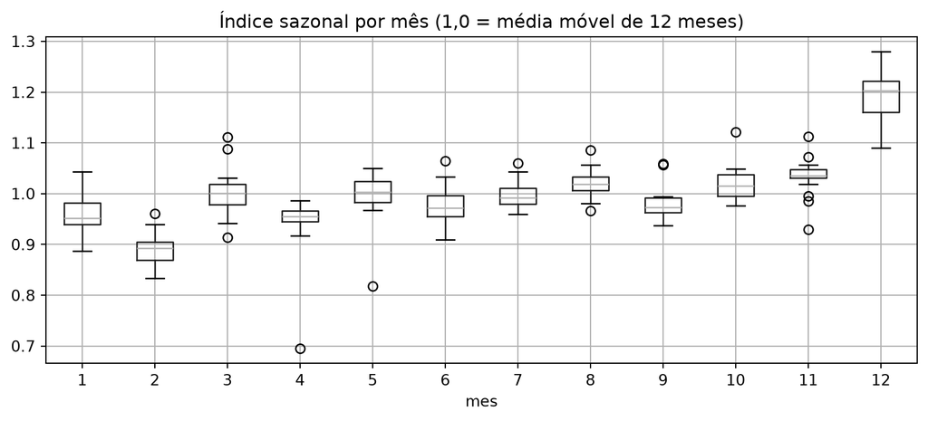

```python
indice = y / y.rolling(12, center=True).mean()   # remove a tendência
(indice.to_frame("indice")
       .assign(mes=indice.index.month)
       .boxplot(column="indice", by="mes", figsize=(10, 4)))
plt.suptitle("")
plt.title("Índice sazonal por mês (1,0 = média móvel de 12 meses)")
plt.show()
```

## ACF e PACF

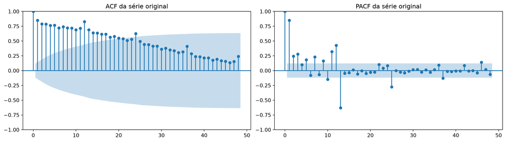

```python
fig, ax = plt.subplots(1, 2, figsize=(14, 4))
plot_acf(y, lags=48, ax=ax[0], title="ACF da série original")
plot_pacf(y, lags=48, ax=ax[1], title="PACF da série original", method="ywm")
plt.tight_layout()
plt.show()
```

Tendência. Achado: crescimento até 2013, queda até 2016 e platô desde 2021, sem tendência recente de alta. Evidência: média anual de 57,8 (2004), 109,5 (2013), 89,9 (2016) e entre 100 e 104 (2021 a 2025); ACF com decaimento lento. Implicação: série não estacionária em nível, com d = 1 provável.

Choques. Achado: a recessão de 2014-2016 foi lenta e prolongada; a queda de 2020 foi abrupta e curta (68,7 em abril, 93,4 em junho). Implicação: são episódios atípicos que podem aparecer nos resíduos do modelo e ampliar a incerteza das previsões.

Sazonalidade. Achado: dezembro forte (1,20), fevereiro fraco (0,89), novembro modesto (1,04). Evidência: PACF com barras significativas nos lags 12, 13 e 25. Implicação: diferença sazonal (D = 1) provável, a confirmar com nsdiffs e testes ADF e KPSS.

## Estacionariedade

```python
from statsmodels.tsa.stattools import adfuller, kpss
from statsforecast.arima import ndiffs, nsdiffs

print("nsdiffs:", nsdiffs(y.values, period=12), "| ndiffs:", ndiffs(y.values))

def testes(x, nome):
    x = x.dropna()
    print(nome, "ADF p=%.4f | KPSS p=%.4f" % (
        adfuller(x, autolag="AIC")[1], kpss(x, regression="c", nlags="auto")[1]))

testes(y, "original")
testes(y.diff(12), "D=1")
testes(y.diff(12).diff(), "D=1, d=1")
```

```
nsdiffs: 1 | ndiffs: 1
original ADF p=0.2111 | KPSS p=0.0100
D=1 ADF p=0.1253 | KPSS p=0.0362
D=1, d=1 ADF p=0.0000 | KPSS p=0.1000
```

# Modelagem

## AutoARIMA

```python
from statsforecast import StatsForecast
from statsforecast.models import AutoARIMA

sf = StatsForecast(models=[AutoARIMA(season_length=12)], freq="MS", n_jobs=1)
sf.fit(df_sf)

modelo = sf.fitted_[0, 0].model_
p, q, P, Q, s, d, D = modelo["arma"]
print(f"(p,d,q)(P,D,Q)[s] = ({p},{d},{q})({P},{D},{Q})[{s}]")
print(modelo["coef"])
print("AICc:", modelo["aicc"])
```

```
(p,d,q)(P,D,Q)[s] = (2,1,1)(0,1,1)[12]
{'ar1': np.float64(0.5066101107183072), 'ar2': np.float64(0.0018562875667761558), 'ma1': np.float64(-0.801994413598873), 'sma1': np.float64(-0.8585820250925582)}
AICc: 1446.5433983059515
```

## Resíduos

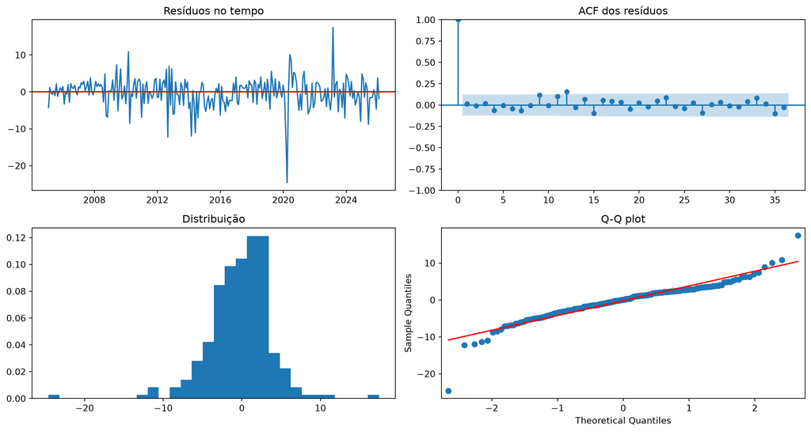

```
    lb_stat  lb_pvalue
12  15.9912     0.0425
24  25.3917     0.1869
```

```python
import numpy as np
import matplotlib.pyplot as plt
from statsmodels.graphics.tsaplots import plot_acf
from statsmodels.graphics.gofplots import qqplot
from statsmodels.stats.diagnostic import acorr_ljungbox

res = pd.Series(np.asarray(modelo["residuals"]), index=y.index).iloc[d + D * s:]

fig, ax = plt.subplots(2, 2, figsize=(13, 7))
ax[0, 0].plot(res); ax[0, 0].axhline(0, color="red"); ax[0, 0].set_title("Resíduos no tempo")
plot_acf(res, lags=36, ax=ax[0, 1], title="ACF dos resíduos")
ax[1, 0].hist(res, bins=30, density=True); ax[1, 0].set_title("Distribuição")
qqplot(res, line="s", ax=ax[1, 1]); ax[1, 1].set_title("Q-Q plot")
plt.tight_layout(); plt.show()

print(acorr_ljungbox(res, lags=[12, 24], model_df=p + q + P + Q).round(4))
```